# boxplot.by.node

Nick Crouch

May 6 2019

In a current project, I have a need to show boxplots showing distributions of values at some (not all) internal nodes in a phylogeny. The function *plotTree.boxplot* already exists in the wonderful package *phytools* for showing boxplots next to tips, here I present the function *boxplot.by.node*.

```r
source("boxplot.by.node.R")
```

The function can be downloaded here. *boxplot.by.node* takes the following arguments:

- `phy`: An object of class `phylo`.
- `dat`: A `data.frame` containing the information for the nodes. Further details below
- `label.nodes`: Logical, should the target nodes be shown?
- `show.tip.labels`: Logical, should the tip labels be shown?
- `node.cols`: A `character` vector used to color code the nodes.
- `color.boxplot`: Logical, should the boxplots be colored as well as the phylogeny nodes?
- `...`: Additional arguments to be passed to `boxplot`.

The function requires *phytools* to be installed

```r
library(phytools)
```

To demonstrate the function, let’s generate some dummy data.

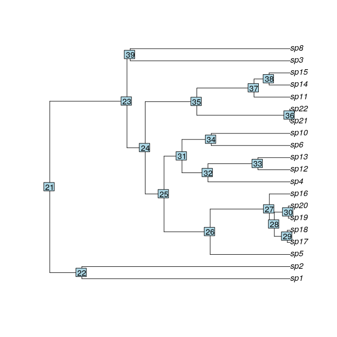

```r
# Not required for the function to run, but used here to generate an example tree
library(diversitree)

# for replication
set.seed(66)
phy <- tree.bd(pars=c(0.3,0.01), max.taxa = 20)

plot(phy)
nodelabels()
```

Let’s say we have data for nodes 39, 32, and 22 that we would like to visualize such that we want the boxplot to be arranged in that order top to bottom. This is easy to do if we have a manageable number of nodes, but automating the procedure will undoubtably by a time-saver for all those lovely large phylogenies out there. So, let’s generate some dummy data and check out the function. **Note**, this function requires that the column names are named as presented here (node_[node number]). For large data sets, this will need to be considered upstream in any workflows.

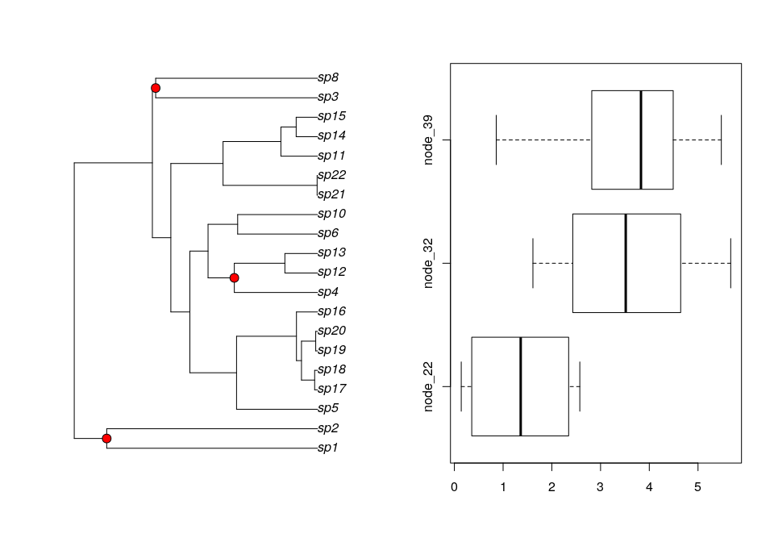

```r
source("boxplot.by.node.R")

# Data is currently out of order
my.plot.dat <- data.frame(node_22 = rnorm(n = 10, mean = 1, sd = 1),
                          node_39 = rnorm(n = 10, mean = 5, sd = 2),
                          node_32 = rnorm(n = 10, mean = 3, sd = 1.5))

boxplot.by.node(phy, my.plot.dat, label.nodes = TRUE, node.cols = "red", color.boxplot = FALSE)
```

Alternatively, let’s color code each of the individual nodes and corresponding boxplots.

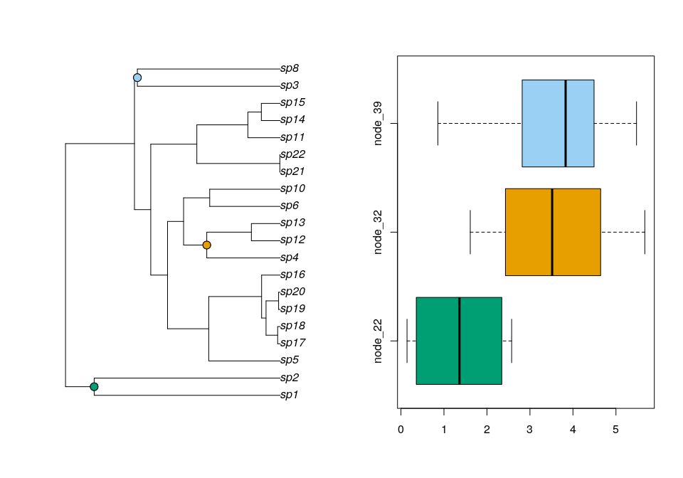

```r
boxplot.by.node(phy, my.plot.dat, label.nodes = TRUE,
                node.cols = c("#009E73", "#e79f00", "#9ad0f3"),
                color.boxplot = TRUE)
```

The function allows extra arguments to be passed to `boxplot`. For example, let’s label our axes.

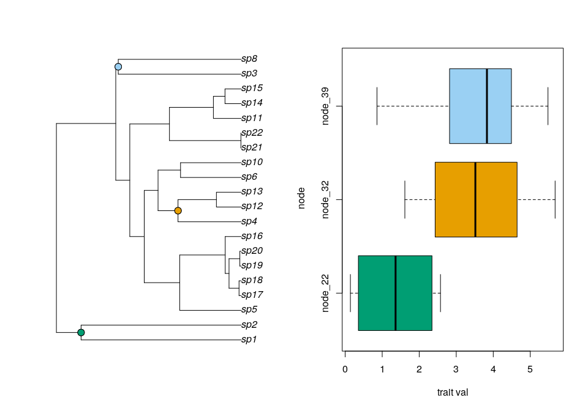

```r
boxplot.by.node(phy, my.plot.dat, label.nodes = TRUE,
                node.cols = c("#009E73", "#e79f00", "#9ad0f3"),
                color.boxplot = TRUE, xlab="trait val", ylab=" node")
```